## Loading and Preprocessing the data

The reported data activity (.csv) file data is copied into R for further data analysis. The data has a lot of NA values which are ignored for this part of the analysis. The sum of the number of steps per date is calculated.

```r
data <- read.csv('C:/Users/Binu/Documents/repdata-data-activity/activity.csv');
data$steps <- as.numeric(data$steps);
data$interval <- as.numeric(data$interval);
```

## What is mean total number of steps taken per day?

#### A histogram of the total number of steps per date is shown below

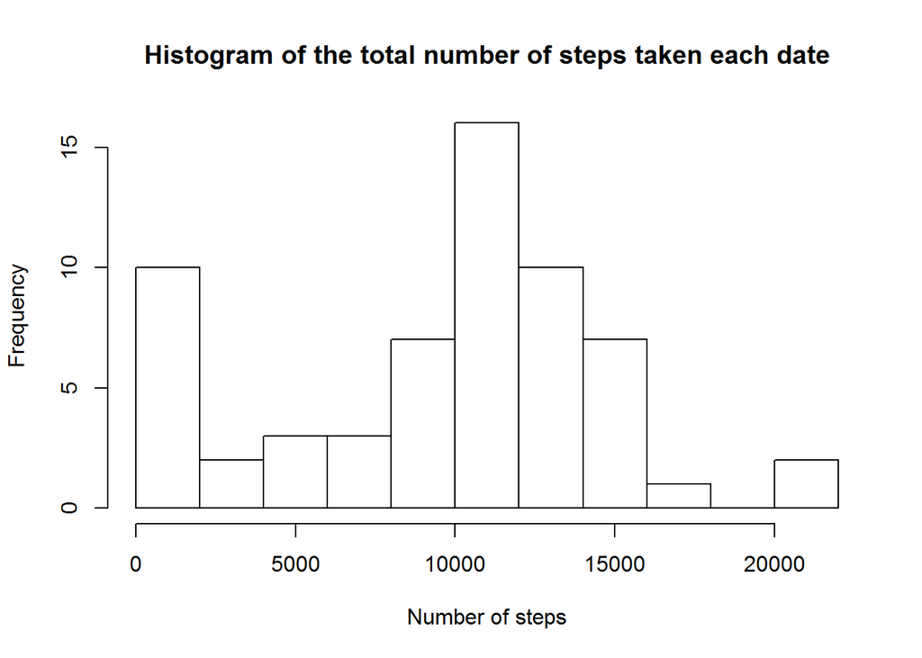

```r
aggdata <-aggregate(data$steps,list(date = data$date), FUN="sum", na.rm=TRUE);
hist(aggdata$x,breaks = 15,main = "Histogram of the total number of steps taken each date",xlab = 'Number of steps');
```

```r
avgData <-aggregate(data$steps,list(date = data$date), FUN="mean", na.rm=TRUE);
```

```
##          date          x
## 1  2012-10-01        NaN
## 2  2012-10-02  0.4375000
## 3  2012-10-03 39.4166667
## 4  2012-10-04 42.0694444
## 5  2012-10-05 46.1597222
## 6  2012-10-06 53.5416667
## 7  2012-10-07 38.2465278
## 8  2012-10-08        NaN
## 9  2012-10-09 44.4826389
## 10 2012-10-10 34.3750000
## 11 2012-10-11 35.7777778
## 12 2012-10-12 60.3541667
## 13 2012-10-13 43.1458333
## 14 2012-10-14 52.4236111
```

[output cut: 47 more lines]

```r
medData <-aggregate(data$steps,list(date = data$date), FUN="median", na.rm=TRUE)
```

```
##          date  x
## 1  2012-10-01 NA
## 2  2012-10-02  0
## 3  2012-10-03  0
## 4  2012-10-04  0
## 5  2012-10-05  0
## 6  2012-10-06  0
## 7  2012-10-07  0
## 8  2012-10-08 NA
## 9  2012-10-09  0
## 10 2012-10-10  0
## 11 2012-10-11  0
## 12 2012-10-12  0
## 13 2012-10-13  0
## 14 2012-10-14  0
```

[output cut: 47 more lines]

## What is the average daily activity pattern?

#### Time series plot of the 5-minute interval (x-axis) and the average number of steps taken, averaged across all days (y-axis)

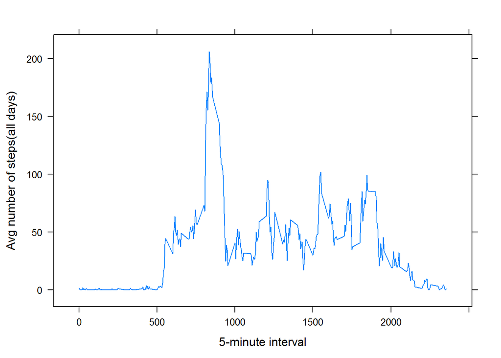

```r
xyplot(avgDailyPattern$x ~avgDailyPattern$interval,avgDailyPattern,type ="l",xlab = "5-minute interval",ylab = "Avg number of steps(all days)")
```

#### The 5-minute interval with the maximum number of steps, on average across all the days in the dataset

```r
avgDailyPattern[avgDailyPattern$x==max(avgDailyPattern$x),]
```

```
##     interval        x
## 104      835 206.1698
```

## Imputing missing values

#### The total number of missing values in the dataset

```r
sum(is.na(data$steps))
```

```
## [1] 2304
```

#### The missing step values are imputed using the mean for that 5 minute interval and creating a new dataset using this imputed data

```r
avgIntData <-aggregate(data$steps,by=list(interval = data$interval), FUN=mean,na.rm =TRUE);

# Impute data
imputedData <- data;
for (i in 1:length(avgIntData$x))
 {
  imputedData$steps[is.na(data$steps) & data$interval==avgIntData$interval[i]] <- avgIntData$x[i];
 }
aggImpData <-aggregate(imputedData$steps,list(date = imputedData$date), FUN="sum", na.rm=TRUE);
```

#### The histogram of total number of steps taken per day are recalculated using the imputed data.

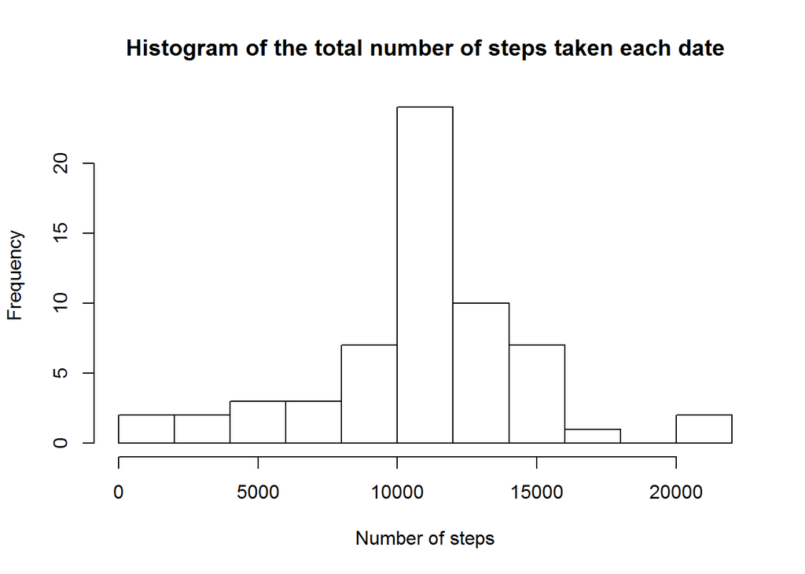

```r
hist(aggImpData$x,breaks = 15,main = "Histogram of the total number of steps taken each date",xlab = 'Number of steps');
```

```r
avgImpData <-aggregate(imputedData$steps,list(date = imputedData$date), FUN="mean", na.rm=TRUE);
```

#### Around 2304 new columns now have a value. There is a noticeable increase in the frequency of number of steps between 8000 and 12000

```
##          date          x
## 1  2012-10-01 37.3825996
## 2  2012-10-02  0.4375000
## 3  2012-10-03 39.4166667
## 4  2012-10-04 42.0694444
## 5  2012-10-05 46.1597222
## 6  2012-10-06 53.5416667
## 7  2012-10-07 38.2465278
## 8  2012-10-08 37.3825996
## 9  2012-10-09 44.4826389
## 10 2012-10-10 34.3750000
## 11 2012-10-11 35.7777778
## 12 2012-10-12 60.3541667
## 13 2012-10-13 43.1458333
## 14 2012-10-14 52.4236111
```

[output cut: 47 more lines]

```r
medImpData <-aggregate(imputedData$steps,list(date = imputedData$date), FUN="median", na.rm=TRUE);
```

```
##          date        x
## 1  2012-10-01 34.11321
## 2  2012-10-02  0.00000
## 3  2012-10-03  0.00000
## 4  2012-10-04  0.00000
## 5  2012-10-05  0.00000
## 6  2012-10-06  0.00000
## 7  2012-10-07  0.00000
## 8  2012-10-08 34.11321
## 9  2012-10-09  0.00000
## 10 2012-10-10  0.00000
## 11 2012-10-11  0.00000
## 12 2012-10-12  0.00000
## 13 2012-10-13  0.00000
## 14 2012-10-14  0.00000
```

[output cut: 47 more lines]

## Are there differences in activity patterns between weekdays and weekends?

#### Creating a new factor variable in the dataset with two levels - “Weekday” and “Weekend” indicating whether a given date is a weekday or weekend day.

```r
day <- weekdays(as.POSIXct(imputedData$date));
day[day=="Sunday"| day=="Saturday"] <- "Weekend";
day[day!="Weekend"] <- "Weekday";

# adding this to the dataset
imputedData$Day <- day;
#
```

#### Plot containing the 5-minute interval (x-axis) and the average number of steps taken, averaged across all weekday days or weekend days (y-axis)

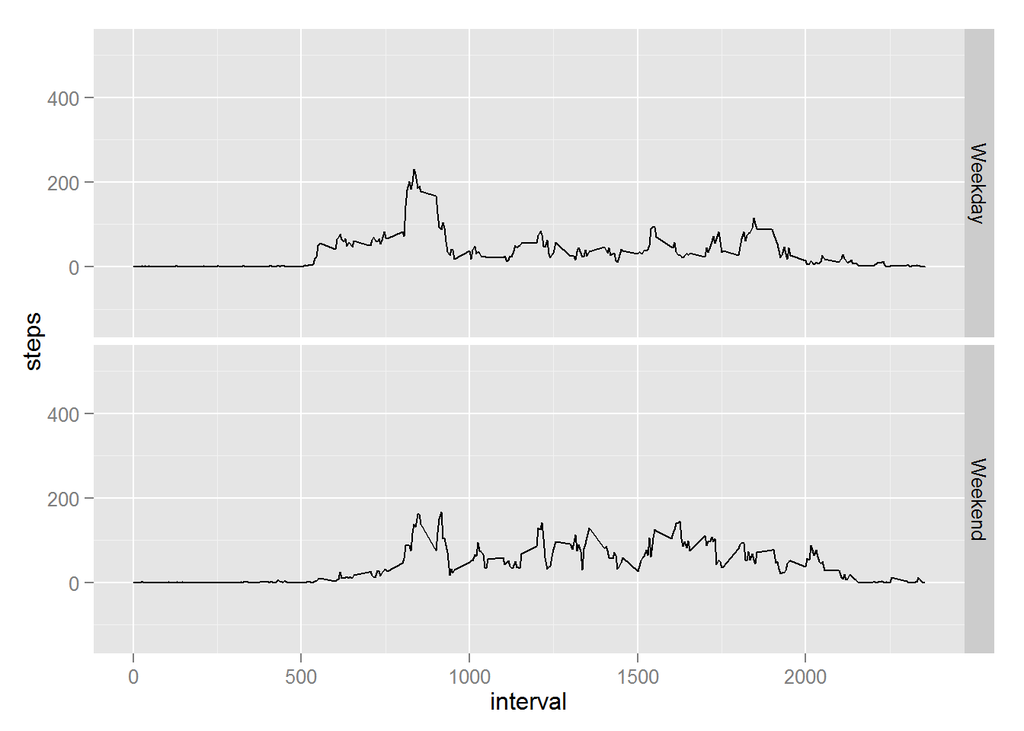

```r
 library(ggplot2)
 p<- ggplot(imputedData,aes(x =interval,y = steps));

 p + stat_summary(fun.y = mean,fun.ymin = function(x) mean(x) - sd(x), fun.ymax = function(x) mean(x) + sd(x),geom = "line")       +facet_grid(Day~.)
```